# Оплата курса

## 1. Об отчете

### Исследовательские вопросы

1. Как плата за курс влияет на нормализованное количество посещенных страниц?
2. Как тип курса влияет на оплату курса?
3. Как плата за курс и тип курса влияет на количество посещенных страниц?
4. Как разные формы оплаты влияют на нормализованное количество посещенных страниц?
5. Как нормализованное количество посещенных страниц влияет на вероятность оплатить курс?

### Содержание отчета

1. Влияние платы за курс на количество посещенных страниц
2. Влияние платы за курс и программирования на количество посещенных страниц
3. Влияние типа оплаты за курс на количество посещенных страниц
4. Влияние нормализованного количество посещенных страниц на вероятность оплатить курс

### Переменные

- **Посещение форума.**
  - *vis_b* - посещал форум или нет;
  - *vis_p* - количество посещенных страниц форума;
  - *vis_p_n* - нормализованное количество посещенных страниц = число посещенных страниц / среднее число посещенных страниц на курсе;
- **Тип курса.**
  - *spec_b* - индивидуальный курс или курс из специализации;
  - *is_prog_b* - есть задания по программированию в курсе или нет;
- **Оплата.**
  - *was_pay* равна 1 если был получен сертификат т.е.
  - *what_pay*
    - курс был оплачен самим пользователем;
    - ему дали финансовую помощь;
    - ему дали групповую поддержку (например в рамках программы для образовательных учреждений);

### 2. Связь платы за курс и нормализованного количества посещенных страниц

#### Обоснование выбора переменных и визуализация

```r
with(students, tapply(vis_p, was_pay, function(x) {
    sprintf("M (SD) = %1.2f (%1.2f)", mean(x, na.rm =TRUE), sd(x, na.rm =TRUE))
}))
```

```
##                         0                         1
## "M (SD) = 68.62 (176.58)" "M (SD) = 64.89 (131.63)"
```

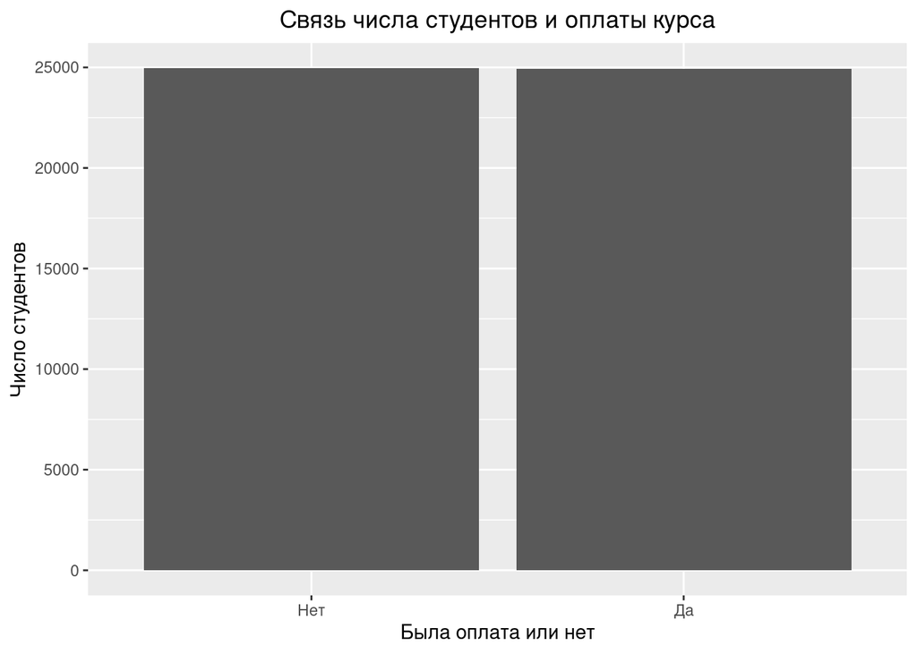

```r
students %>% ggplot(aes(factor(was_pay), ..count..)) + geom_bar() + ggtitle("Связь числа студентов и оплаты курса") + labs(x="Была оплата или нет", y = "Число студентов")  +  scale_x_discrete(labels=c("Нет", "Да")) + theme(plot.title = element_text(hjust = 0.5))
```

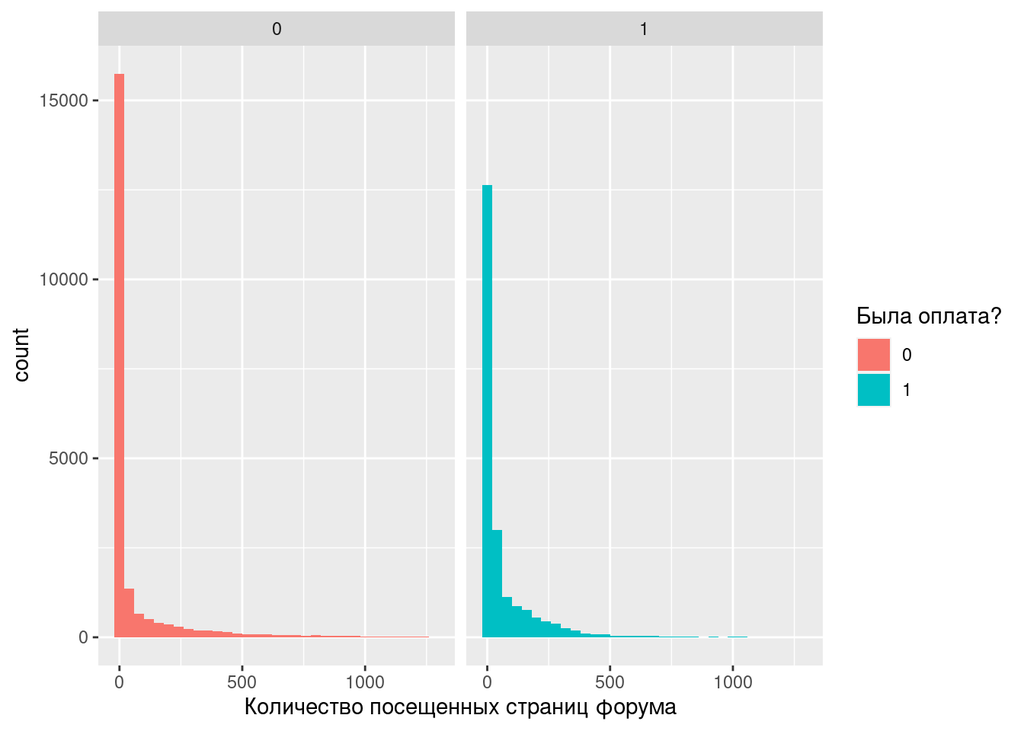

```r
ggplot(students, aes(vis_p, fill = factor(was_pay))) + geom_histogram(binwidth = 40) + facet_grid(~was_pay) + labs(x="Количество посещенных страниц форума", fill = "Была оплата?")
```

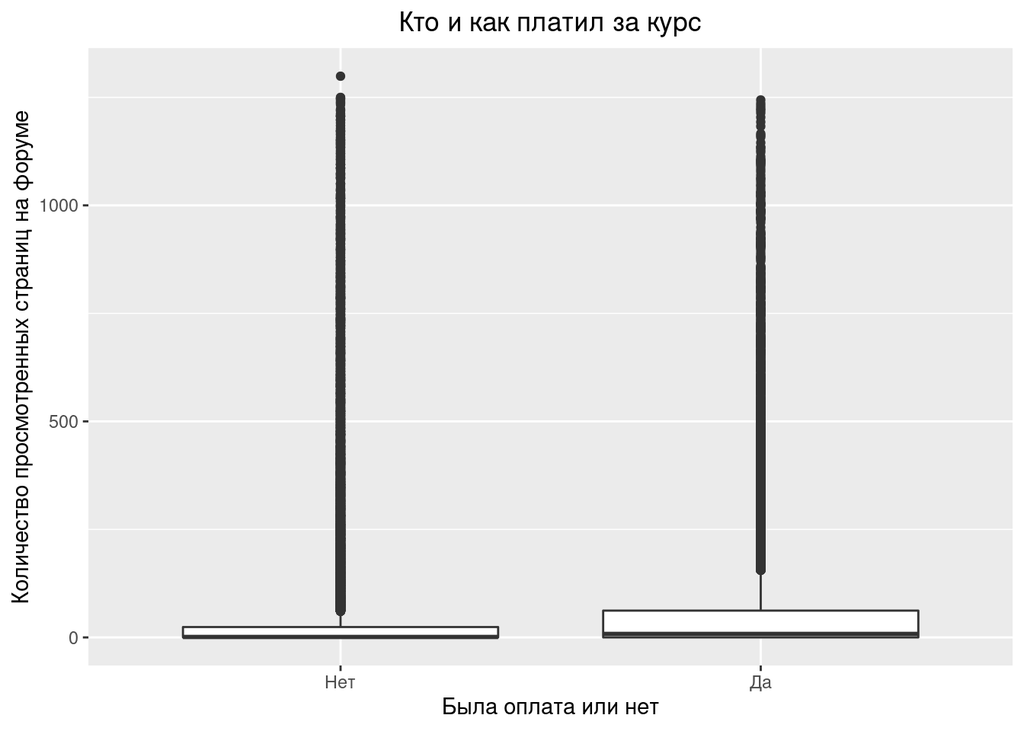

```r
students %>% ggplot(aes(x = factor(was_pay), y = vis_p)) + geom_boxplot() + ggtitle("Кто и как платил за курс") + labs(x="Была оплата или нет", y = "Количество просмотренных страниц на форуме") + scale_x_discrete(labels=c("Нет", "Да")) +  theme(plot.title = element_text(hjust = 0.5))
```

```r
students %>% group_by(was_pay) %>% summarise(mean_visit = mean(vis_p, na.rm = TRUE))
```

```
## # A tibble: 2 x 2
##   was_pay mean_visit
##     <int>      <dbl>
## 1       0       68.6
## 2       1       64.9
```

Выбор статистических инструментов:

- Переменная vis_p счетная, для таких переменных используется пуассоновское или отрицательно-биномиальное распределение.
- Overdispersion test, odTest(), поможет нам выбрать необходимое распределение. Оно проверяет верно ли необходимое условие для использование Пуассоновской регрессии - равенство условного среднего и условного распределения. Если значение p-value меньше 0.05, то гипотеза о чрезмерной дисперсии не может быть отброшена. В таком случае следует применять отрицательно-биномиальное распределение.
- Для обратной трансформации мы используем функцию invlogit().
- Поскольку на каждом курсе посещения могут быть по разному распределены, используем нормализованное значение посещений форума - vis_p_n.

```
## Likelihood ratio test of H0: Poisson, as restricted NB model:
## n.b., the distribution of the test-statistic under H0 is non-standard
## e.g., see help(odTest) for details/references
##
## Critical value of test statistic at the alpha= 0.05 level: 2.7055
## Chi-Square Test Statistic =  Inf p-value = < 2.2e-16
```

```r
wt1 <- wilcox.test(vis_p ~ was_pay, students)
w1 <- students %>% wilcox_effsize(vis_p_n ~ was_pay)
wt1
```

```
##
##  Wilcoxon rank sum test with continuity correction
##
## data:  vis_p by was_pay
## W = 173371647, p-value < 2.2e-16
## alternative hypothesis: true location shift is not equal to 0
```

```r
w1
```

```
## # A tibble: 1 x 7
##   .y.     group1 group2 effsize    n1    n2 magnitude
## * <chr>   <chr>  <chr>    <dbl> <int> <int> <ord>
## 1 vis_p_n 0      1        0.131 24961 24942 small
```

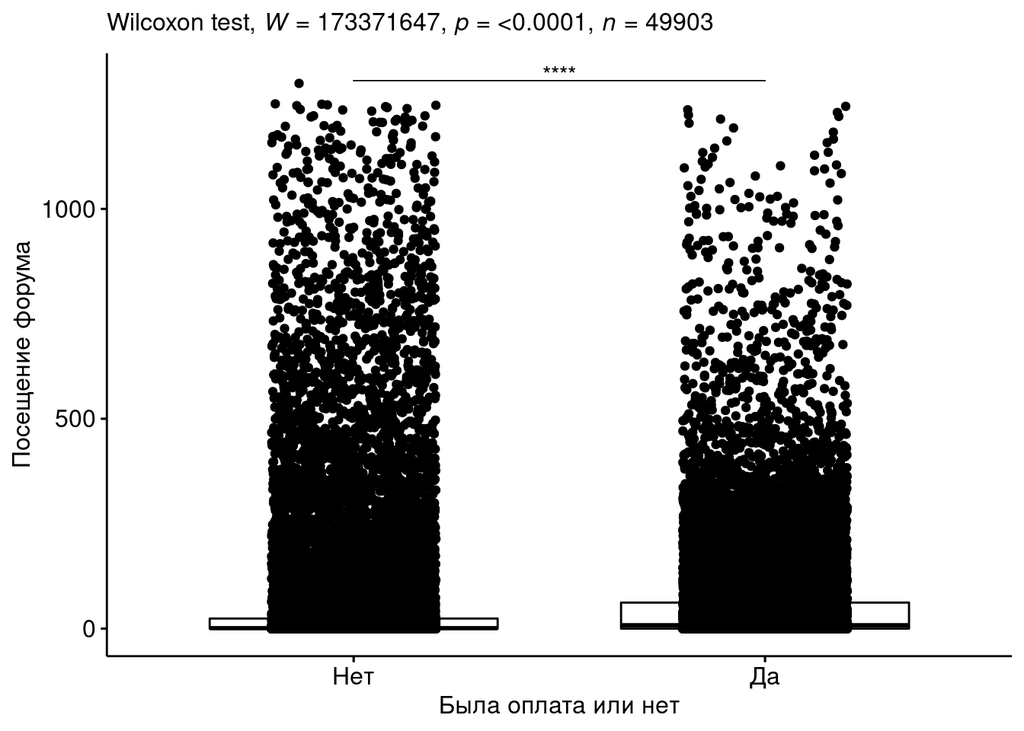

```r
stat.test <- students %>%
  wilcox_test(vis_p ~ was_pay) %>%
  add_significance()
bxp <- ggboxplot(
  students, x = "was_pay", y = "vis_p",
  ylab = "Посещение форума", xlab = "Была оплата или нет", add = "jitter") +
scale_x_discrete(labels=c("Нет","Да"))
stat.test <- stat.test %>% add_xy_position(x = "group")
bxp +
  stat_pvalue_manual(stat.test, tip.length = 0) +
  labs(subtitle = get_test_label(stat.test, detailed = TRUE))
```

#### Анализ дисперсии переменной was_pay

```r
m0 <-  glmer(factor(was_pay) ~ 1 + (1|course_id), family = "binomial", students)
summary(m0)
```

```
## Generalized linear mixed model fit by maximum likelihood (Laplace
##   Approximation) [glmerMod]
##  Family: binomial  ( logit )
## Formula: factor(was_pay) ~ 1 + (1 | course_id)
##    Data: students
##
##      AIC      BIC   logLik deviance df.resid
##  56471.0  56488.6 -28233.5  56467.0    49901
##
## Scaled residuals:
##     Min      1Q  Median      3Q     Max
## -5.4208 -0.8656 -0.0246  0.7168  4.4714
##
## Random effects:
##  Groups    Name        Variance Std.Dev.
##  course_id (Intercept) 4.658    2.158
## Number of obs: 49903, groups:  course_id, 60
##
## Fixed effects:
##             Estimate Std. Error z value Pr(>|z|)
## (Intercept)  -0.1098     0.2629  -0.418    0.676
```

```r
m0 <-  glm(factor(was_pay) ~ vis_b, family = "binomial", students)
summary(m0)
```

```
##
## Call:
## glm(formula = factor(was_pay) ~ vis_b, family = "binomial", data = students)
##
## Deviance Residuals:
##     Min       1Q   Median       3Q      Max
## -1.2997  -1.2997  -0.9403   1.0599   1.4347
##
## Coefficients:
##             Estimate Std. Error z value Pr(>|z|)
## (Intercept) -0.58701    0.01624  -36.14   <2e-16 ***
## vis_b        0.86989    0.01965   44.28   <2e-16 ***
## ---
## Signif. codes:  0 '***' 0.001 '**' 0.01 '*' 0.05 '.' 0.1 ' ' 1
##
## (Dispersion parameter for binomial family taken to be 1)
##
##     Null deviance: 69180  on 49902  degrees of freedom
## Residual deviance: 67156  on 49901  degrees of freedom
## AIC: 67160
##
## Number of Fisher Scoring iterations: 4
```

```r
tab_model(m0)
```

|  | factor(was pay) |  |  |
| --- | --- | --- | --- |
| Predictors | Odds Ratios | CI | p |
| (Intercept) | 0.56 | 0.54 – 0.57 | **<0.001** |
| vis_b | 2.39 | 2.30 – 2.48 | **<0.001** |
| Observations | 49903 |  |  |
| R<sup>2</sup> Tjur | 0.040 |  |  |

Likelihood ratio:

```r
modelChi <- m0$null.deviance - m0$deviance
modelChi
```

```
## [1] 2024.62
```

```r
chidf <- m0$df.null - m0$df.residual
chidf
```

```
## [1] 1
```

```r
chisq.prob <- 1 - pchisq(modelChi, chidf)
chisq.prob
```

```
## [1] 0
```

```r
R2.hl<-modelChi/m0$null.deviance
R2.hl
```

```
## [1] 0.02926587
```

```r
confint(m0)
```

```
##                  2.5 %     97.5 %
## (Intercept) -0.6188949 -0.5552299
## vis_b        0.8314246  0.9084364
```

#### Интерпретация регрессии:

```
## Вероятность оплатить курс, если не заходил на форум: 0.3573.
```

```
## Вероятность оплатить курс, если заходил на форум хотя бы раз: 0.57.
```

[output not shown]

```
## Шанс оплатить курс, если не заходил на форум: 1 к 0.556.
```

```
## Шанс оплатить курс, если заходил на форум: 1 к 1.327.
```

[output not shown]

#### Визуализируем взаимосвязь

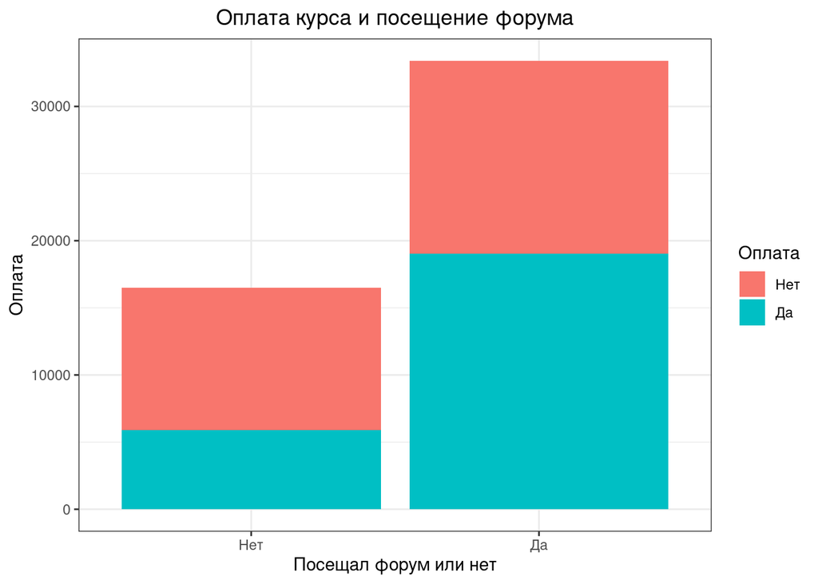

```r
students  %>% ggplot(aes(x = factor(vis_b), fill = factor(was_pay))) +
  geom_bar() +
  scale_fill_hue() +
# напечатает легенду, название графика и осей
  ggtitle("Оплата курса и посещение форума") +
  scale_color_discrete(labels=c("Без оплаты", "С оплатой")) +
  labs(x = "Посещал форум или нет", y = "Оплата", fill = "Оплата") +
  scale_x_discrete(labels=c("Нет", "Да")) +
  scale_fill_discrete(labels=c("Нет", "Да")) +
# задает цветовую тему графика
  theme_bw() +
# выравнивает название по центру
  theme(plot.title = element_text(hjust = 0.5))
```

### 3. Влияние платы за курс и программирования на количество посещенных страниц

#### 3.1. Тип курса и оплата курса

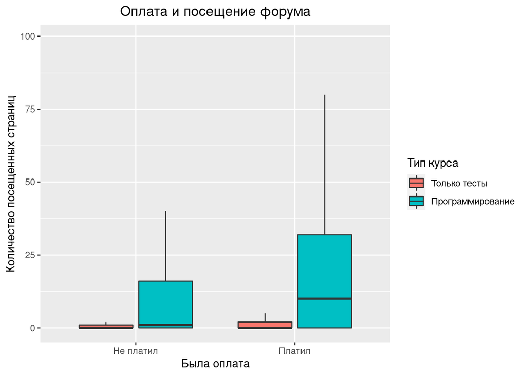

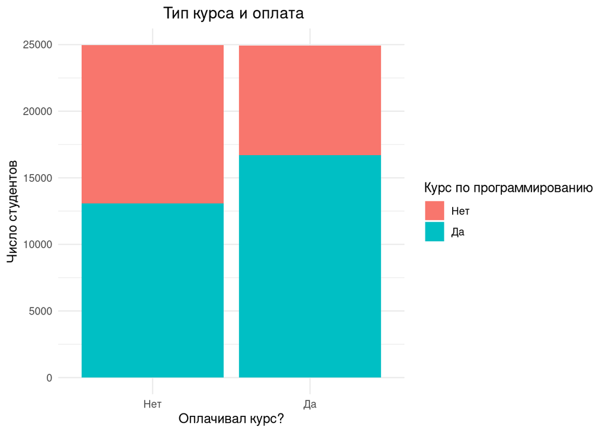

Таблица сопряженности:

```r
chisq <- chisq.test(tab)
chisq
```

```
##
##  Pearson's Chi-squared test with Yates' continuity correction
##
## data:  tab
## X-squared = 1090.3, df = 1, p-value < 2.2e-16
```

#### Интерпретация теста хи-квадрат:

```
## Существует значимая связь между платой за курс и курсом с программированием: X-squared = 1090.29, p-value = 0.00.
```

```
## Шанс оплаты курса для курса с программированием в 1.837 (1.771 и 1.905) раза выше, чем для курса без программирования
## * высокая оценка = оценка выше медианы по курсу
```

Для хи-квадрата отношение шансов - это мера оценки размера эффекта.

Цель раздела: понять имеет ли форум влияние на вероятность приобрести сертификат или является всего лишь модератор связи типом курса и приобретением сертификата

```r
m1 <-  glm(factor(was_pay) ~ vis_b*factor(is_prog_b), family="binomial", students)
summary(m1)
```

```
##
## Call:
## glm(formula = factor(was_pay) ~ vis_b * factor(is_prog_b), family = "binomial",
##     data = students)
##
## Deviance Residuals:
##     Min       1Q   Median       3Q      Max
## -1.3630  -1.1631  -0.8875   1.0026   1.4982
##
## Coefficients:
##                          Estimate Std. Error z value Pr(>|z|)
## (Intercept)              -0.72852    0.02145 -33.961  < 2e-16 ***
## vis_b                     0.69467    0.02918  23.805  < 2e-16 ***
## factor(is_prog_b)1        0.34356    0.03298  10.416  < 2e-16 ***
## vis_b:factor(is_prog_b)1  0.11655    0.04074   2.861  0.00423 **
## ---
## Signif. codes:  0 '***' 0.001 '**' 0.01 '*' 0.05 '.' 0.1 ' ' 1
##
## (Dispersion parameter for binomial family taken to be 1)
##
##     Null deviance: 69180  on 49902  degrees of freedom
## Residual deviance: 66677  on 49899  degrees of freedom
## AIC: 66685
##
## Number of Fisher Scoring iterations: 4
```

```r
vif(m1)
```

```
##                   vis_b       factor(is_prog_b) vis_b:factor(is_prog_b)
##                2.188527                3.092899                4.899457
```

```r
tab_model(m1)
```

|  | factor(was pay) |  |  |
| --- | --- | --- | --- |
| Predictors | Odds Ratios | CI | p |
| (Intercept) | 0.48 | 0.46 – 0.50 | **<0.001** |
| vis_b | 2.00 | 1.89 – 2.12 | **<0.001** |
| is_prog_b [1] | 1.41 | 1.32 – 1.50 | **<0.001** |
| vis_b * is_prog_b [1] | 1.12 | 1.04 – 1.22 | **0.004** |
| Observations | 49903 |  |  |
| R<sup>2</sup> Tjur | 0.049 |  |  |

Likelihood ratio:

```r
modelChi <- m1$null.deviance - m1$deviance
modelChi
```

```
## [1] 2503.528
```

```r
chidf <- m1$df.null - m1$df.residual
chidf
```

```
## [1] 3
```

```r
chisq.prob <- 1 - pchisq(modelChi, chidf)
chisq.prob
```

```
## [1] 0
```

```r
R2.hl<-modelChi/m1$null.deviance
R2.hl
```

```
## [1] 0.03618848
```

```r
confint(m1)
```

```
##                                2.5 %     97.5 %
## (Intercept)              -0.77066501 -0.6865744
## vis_b                     0.63752668  0.7519172
## factor(is_prog_b)1        0.27890813  0.4082042
## vis_b:factor(is_prog_b)1  0.03670306  0.1964095
```

#### Интерпретация регрессии:

```
## Вероятность оплатить курс, если не заходил на форум: 0.3255.
```

```
## Вероятность оплатить курс, если заходил на форум хотя бы раз: 0.49.
```

```
## Вероятность оплатить курс, если курс по программированию: 0.40.
```

[output not shown]

```
## Шанс оплатить курс, если не заходил на форум: 1 к 0.483.
```

```
## Шанс оплатить курс, если заходил на форум: 1 к 0.967.
```

```
## Шанс оплатить курс, если курс по программированию: 0.68.
```

#### Визуализируем взаимосвязь

[figure not shown]

```r
students %>% filter(vis_p < 250) %>%
  ggplot(aes(y = was_pay, x = vis_p, color = factor(is_prog_b))) +   geom_point(aes(color = as.factor(is_prog_b)), shape = 1)   +  geom_smooth(method="glm.nb") + ggtitle("Влияние типа курса и оплаты на\n нормализованное посещение курса") + labs(x="Нормализованные посещения", y = "Вероятность оплатить курс", color = "Тип курса") + scale_color_discrete(labels=c("Без заданий\nс программированием", "С заданиями\nпо программированию"))+  theme(plot.title = element_text(hjust = 0.5))
```

### 5. Влияние типа оплаты за курс на количество посещенных страниц

Выбор статистических инструментов:

```r
summary(aov(vis_b ~ what_pay, students))
```

```
##                Df Sum Sq Mean Sq F value Pr(>F)
## what_pay        3    773  257.58    1251 <2e-16 ***
## Residuals   49899  10275    0.21
## ---
## Signif. codes:  0 '***' 0.001 '**' 0.01 '*' 0.05 '.' 0.1 ' ' 1
```

```r
m1 <-  glm(vis_b ~ factor(what_pay), students, family = "binomial")
summary(m1)
```

```
##
## Call:
## glm(formula = vis_b ~ factor(what_pay), family = "binomial",
##     data = students)
##
## Deviance Residuals:
##     Min       1Q   Median       3Q      Max
## -2.0559  -1.3081   0.5075   1.0521   1.0521
##
## Coefficients:
##                                     Estimate Std. Error z value Pr(>|z|)
## (Intercept)                          0.30202    0.01280  23.589   <2e-16 ***
## factor(what_pay)was_finaid_grant     0.57997    0.03539  16.388   <2e-16 ***
## factor(what_pay)was_group_sponsored  0.22426    0.02588   8.667   <2e-16 ***
## factor(what_pay)was_payment          1.68262    0.03076  54.701   <2e-16 ***
## ---
## Signif. codes:  0 '***' 0.001 '**' 0.01 '*' 0.05 '.' 0.1 ' ' 1
##
## (Dispersion parameter for binomial family taken to be 1)
##
##     Null deviance: 63353  on 49902  degrees of freedom
## Residual deviance: 59453  on 49899  degrees of freedom
## AIC: 59461
##
## Number of Fisher Scoring iterations: 4
```

```r
modelChi <- m1$null.deviance - m1$deviance
modelChi
```

```
## [1] 3899.92
```

```r
chidf <- m1$df.null - m1$df.residual
chidf
```

```
## [1] 3
```

```r
chisq.prob <- 1 - pchisq(modelChi, chidf)
chisq.prob
```

```
## [1] 0
```

```r
R2.hl<-modelChi/m1$null.deviance
R2.hl
```

```
## [1] 0.06155879
```

```r
confint(m1)
```

```
##                                         2.5 %    97.5 %
## (Intercept)                         0.2769435 0.3271334
## factor(what_pay)was_finaid_grant    0.5108500 0.6495853
## factor(what_pay)was_group_sponsored 0.1735992 0.2750356
## factor(what_pay)was_payment         1.6226429 1.7432295
```

```r
tab_model(m1)
```

|  | vis b |  |  |
| --- | --- | --- | --- |
| Predictors | Odds Ratios | CI | p |
| (Intercept) | 1.35 | 1.32 – 1.39 | **<0.001** |
| what_pay [was_finaid_grant] | 1.79 | 1.67 – 1.91 | **<0.001** |
| what_pay [was_group_sponsored] | 1.25 | 1.19 – 1.32 | **<0.001** |
| what_pay [was_payment] | 5.38 | 5.07 – 5.72 | **<0.001** |
| Observations | 49903 |  |  |
| R<sup>2</sup> Tjur | 0.070 |  |  |

#### Интерпретация регрессии:

```
## Шанс зайти на форум тех, кто не оплачивал курс 1 к 1.35.
```

```
## Шанс зайти на форум тех, кто оплачивал курс по финансовой помощи 1 к 2.42.
```

```
## Этот эффект статистически значим: x_squared = 0.58, p = 0.000000.
```

```
## Шанс зайти на форум тех, ктооплачивал курс по групповой помощи 1 к 1.69.
```

```
## Этот эффект статистически значим: x_squared = 0.22, p = 0.000000.
```

```
## Шанс зайти на форум тех, кто оплачивал курс самостоятельно 1 к 7.28.
```

```
## Этот эффект статистически значим: x_squared = 1.68, p = 0.000000.
```

#### Визуализируем взаимосвязь:

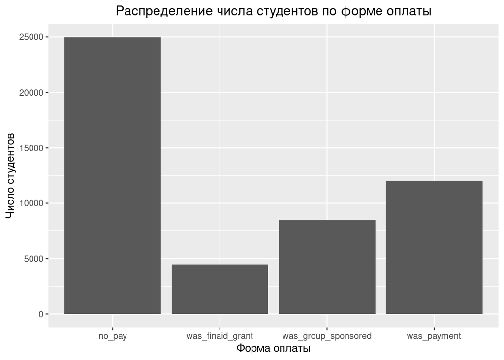

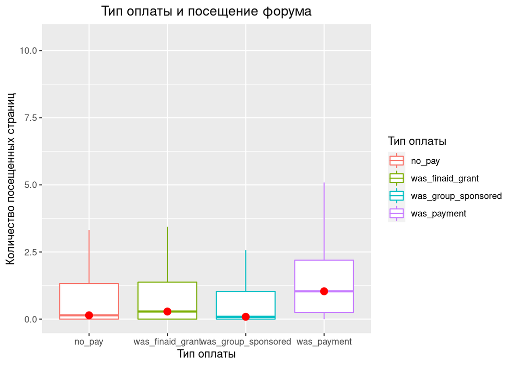

```
## # A tibble: 4 x 2
##   what_pay            mean_vis
##   <chr>                  <dbl>
## 1 no_pay                  68.6
## 2 was_finaid_grant        52.6
## 3 was_group_sponsored     32.9
## 4 was_payment             95.9
```

[figure not shown]

```r
students %>% ggplot(aes(y = vis_p, x = what_pay), group =1) + geom_point() +  geom_smooth(method="glm.nb")  + ggtitle("Тип оплаты и посещение") + labs(y="Форма оплаты", x = "Число студентов")  +  theme(plot.title = element_text(hjust = 0.5))
```

### 5. Влияние нормализованного количество посещенных страниц на вероятность оплатить курс

```r
m0 <- glm(data = students, factor(was_pay) ~ vis_p_n, family = "binomial")
summary(m0)
```

```
##
## Call:
## glm(formula = factor(was_pay) ~ vis_p_n, family = "binomial",
##     data = students)
##
## Deviance Residuals:
##    Min      1Q  Median      3Q     Max
## -1.635  -1.182   1.018   1.157   1.176
##
## Coefficients:
##             Estimate Std. Error z value Pr(>|z|)
## (Intercept) 0.003922   0.012453   0.315    0.753
## vis_p_n     0.098261   0.007418  13.246   <2e-16 ***
## ---
## Signif. codes:  0 '***' 0.001 '**' 0.01 '*' 0.05 '.' 0.1 ' ' 1
##
## (Dispersion parameter for binomial family taken to be 1)
##
##     Null deviance: 54476  on 39368  degrees of freedom
## Residual deviance: 54297  on 39367  degrees of freedom
##   (10534 observations deleted due to missingness)
## AIC: 54301
##
## Number of Fisher Scoring iterations: 4
```

```
## Вероятность студента не посещавшего форум оплатить курс - 0.501.
```

[output not shown]

```
## Например, если студент посетил форум 2 раз, то вероятность, что студент оплатил курс будет равна 0.55
```

```
## Например, если студент посетил форум 3 раз, то вероятность, что студент оплатил курс будет равна 0.57
```

```
## Например, если студент посетил форум 25 раз, то вероятность, что студент оплатил курс будет равна 0.92
```

#### Визуализируем взаимосвязь:

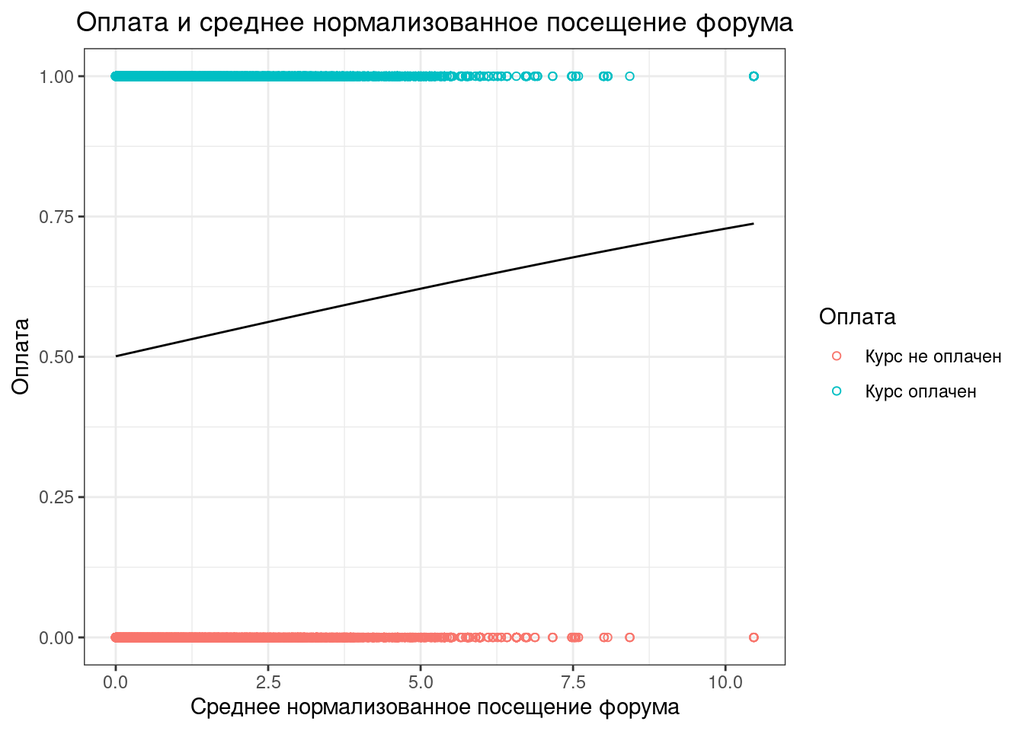

## Выводы

[output not shown]